# Project2

#### Tao SONG (23634999)

### Introduction

The youtube data source is from Kaggle https://www.kaggle.com/datasets/nelgiriyewithana/global-youtube-statistics-2023 This data set is the same data set I used in project 1. There is also a shiny APP provided. You may watch the demo video (https://youtu.be/91HwO5XGKCo) to help you go through the key points.

### Data and libraries set up

Load the required libraries.

```r
library(knitr)
library(shiny)
library(ggplot2)
library(dplyr)
library(pROC)
library(ROCR)
library(ROCit)
library(pander)
library(rpart)
library(class)
library(crayon)
library(caret)
library(FSelector)
library(gridExtra)
library(fpc)
library(ape)
knitr::opts_chunk$set(echo = TRUE)
```

Load the data, youtube 2023 and world 2023 data. World 2023 is also from kaggle https://www.kaggle.com/datasets/nelgiriyewithana/countries-of-the-world-2023 The two data sets are joined by ‘Country’, and only economic related columns, like ‘CPI’, ‘GDP’, ‘Total.tax.rate’, are introduced from world 2023 data set.

```r
youtube_2023data <- read.csv("D:/Downloads/google downloads/data analysis/project2/youtube_UTF_8.csv")
world_2023data <- read.csv("D:/Downloads/google downloads/data analysis/project2/world-data-2023.csv")
#convert the columns to easy handling numerical form
world_2023data <- world_2023data[,c("Country", "CPI", "GDP", "Total.tax.rate")] %>%
  mutate(CPI = as.numeric(CPI)) %>%
  mutate(GDP = as.numeric(gsub("[$,]", "", GDP))) %>%
  mutate(Total.tax.rate = as.numeric(sub('%', '', Total.tax.rate))/ 100)

youtube_2023data <- youtube_2023data %>%
  left_join(world_2023data[,c("Country", "CPI", "GDP", "Total.tax.rate")], by = "Country")
```

### Data preprocessing

To facilitate the further operations, first perform some data preprocessing. Below are some key points:

```r
Sys.setlocale("LC_TIME", "C")
attach(youtube_2023data)
# The 'format' function is added to avoid R transforming Date object to number(number of days from epoch time 1970-01-01)
created_full_date <- format(as.Date(
    paste0(created_year, '-', created_month, '-', created_date),
    "%Y-%b-%d"
  ))
detach(youtube_2023data)

table(youtube_2023data$created_full_date < as.Date("2005-2-14"))
table(youtube_2023data$Gross.tertiary.education.enrollment.... > 100)
youtube_2023data <- youtube_2023data %>%
  rename("Gross.tertiary.education.enrollment.percentage" = "Gross.tertiary.education.enrollment....") %>%
  mutate(created_full_date = format(as.Date(
    paste0(created_year, '-', created_month, '-', created_date),
    "%Y-%b-%d"
  ))) %>%
  mutate(created_full_date = ifelse(
    as.Date(created_full_date) < as.Date("2005-2-14"),
    NA,
    created_full_date
  )) %>%
  mutate(highest_yearly_earnings_cat = cut(highest_yearly_earnings, breaks = c(1000,1000000,Inf), labels = c('low_income','high_income'))) %>%
  mutate(years_exist = as.numeric((as.Date('2023-07-1')-as.Date(created_full_date)))/365) %>%
  mutate(
    Gross.tertiary.education.enrollment.percentage = ifelse(
      Gross.tertiary.education.enrollment.percentage > 100,
      NA,
      Gross.tertiary.education.enrollment.percentage
    )
  )

#remove NA of target variable
youtube_2023data <- youtube_2023data[!is.na(youtube_2023data$highest_yearly_earnings_cat), ]

# yearly uploads less than 10 are removed, as these are abnormal cases for top youtubers
nrow(youtube_2023data[youtube_2023data$uploads==0,])
youtube_2023data$uploads <- ifelse(youtube_2023data$uploads/as.numeric((as.Date('2023-07-1')-as.Date(youtube_2023data$created_full_date))/365)<10, NA, youtube_2023data$uploads)

# video.views equal to 0 are removed, as these are abnormal cases
nrow(youtube_2023data[youtube_2023data$video.views==0,])
youtube_2023data$video.views <- ifelse(youtube_2023data$video.views==0, NA, youtube_2023data$video.views)
```

[output not shown]

Introduce important functions. These are some useful functions originated from lecture slides, some are modified to facilitate operations.

```r
mkPredC <- function(outCol, varCol, appCol, pos) {
  pPos <- sum(outCol == pos) / length(outCol)
  naTab <- table(as.factor(outCol[is.na(varCol)]))
  pPosWna <- (naTab/sum(naTab))[pos]
  vTab <- table(as.factor(outCol), varCol)
  pPosWv <- (vTab[pos, ] + 1.0e-3*pPos) / (colSums(vTab) + 1.0e-3)
  pred <- pPosWv[appCol]
  pred[is.na(appCol)] <- pPosWna
  pred[is.na(pred)] <- pPos
  pred
}

mkPredN <- function(outCol,varCol,appCol, pos) {
  cuts <- unique(as.numeric(quantile(varCol, probs=seq(0, 1, 0.1), na.rm=T)))
  varC <- cut(varCol, cuts)
  appC <- cut(appCol, cuts)
  mkPredC(outCol, varC, appC, pos)
}

calcAUC <- function(predcol,outcol, pos) {
  perf <- performance(prediction(predcol,outcol==pos),'auc')
  as.numeric(perf@y.values)
}

plot_roc <- function(predcol1, outcol1, legend1, predcol2, outcol2, legend2){
    roc_1 <- rocit(score=predcol1, class=outcol1==pos)
    roc_2 <- rocit(score=predcol2, class=outcol2==pos)
    plot(roc_1, col = c("blue","green"), lwd = 3,
      legend = FALSE,YIndex = FALSE, values = TRUE, asp=1)
    lines(roc_2$TPR ~ roc_2$FPR, lwd = 3,
          col = c("red","green"), asp=1)
    legend("bottomright", col = c("blue","red", "green"),
       c(legend1, legend2, "Null Model"), lwd = 2)
}

logLikelihood <- function(ytrue, ypred, epsilon=1e-6) {
sum(ifelse(ytrue==pos, log(ypred+epsilon), log(1-ypred-epsilon)), na.rm=T)
}

performanceMeasures <- function(ytrue, ypred, model.name = "model", threshold=0.5) {
   logLikelihood <- logLikelihood(ytrue, ypred)
   dev.norm <- -2 * logLikelihood(ytrue, ypred)/length(ypred)
   cmat <- table(actual = ytrue, predicted = ypred>0.5)
   accuracy <- sum(diag(cmat)) / sum(cmat)
   precision <- cmat[2, 2] / sum(cmat[, 2])
   recall <- cmat[2, 2] / sum(cmat[2, ])
   f1 <- 2 * precision * recall / (precision + recall)
   data.frame(model = model.name, precision = precision,
              recall = recall, f1 = f1, logLikelihood = logLikelihood, dev.norm = dev.norm)
}

panderOpt <- function(){
  panderOptions("plain.ascii", TRUE)
  panderOptions("keep.trailing.zeros", TRUE)
  panderOptions("table.style", "simple")

}

pretty_perf_table <- function(xpred, xtrue, xlegend,
                              ypred, ytrue, ylegend) {
   panderOpt()
   perf_justify <- "lrrrrr"

   xperf_df <- performanceMeasures(
      xtrue, xpred, model.name=xlegend)
   yperf_df <- performanceMeasures(
      ytrue, ypred, model.name=ylegend)

   perftable <- rbind(xperf_df, yperf_df)
   pandoc.table(perftable, justify = perf_justify)
}
```

### Classification

#### Single Variable Models

Remove some rank and id columns from candidate feature columns; and earnings related columns are also removed, as they should be duplicate to our target variable. Data set is split into training, calibration and test with 8:1:1 ratio, using random separation method with an initial seed to ensure reproducibility.

```r
outcome <- 'highest_yearly_earnings_cat'
pos <- 'high_income'

vars <- setdiff(colnames(youtube_2023data), c('lowest_monthly_earnings', 'highest_monthly_earnings', 'lowest_yearly_earnings', 'highest_yearly_earnings', 'rank', 'Youtuber', 'Title', 'channel_type_rank', 'video_views_rank', 'country_rank', outcome))
catVars <- vars[sapply(youtube_2023data[,vars], class) %in%
                  c('factor','character')]

numericVars <- vars[sapply(youtube_2023data[,vars], class) %in%
                      c('numeric','integer')]

feature_catVars <- catVars
feature_numericVars <- numericVars

set.seed(4009)
random <- runif(dim(youtube_2023data)[[1]])
dTrain <- subset(youtube_2023data,random<=0.8)
dCal  <- subset(youtube_2023data,random>0.8&random<0.9)
dTest <- subset(youtube_2023data,random>=0.9)

dTrainAll <- rbind(dTrain,dCal)
```

Evaluation of Null model. Null model will work as a benchmark for performance check, other models should outperform the Null model.

```r
Npos <- sum(dTrain[,outcome] == pos)
pred.Null <- Npos / nrow(dTrain)
cat("Proportion of outcome == 'high_income' in dTrain:", pred.Null, "\n")
```

```
## Proportion of outcome == 'high_income' in dTrain: 0.8143075
```

```r
TP <- 0; TN <- sum(dCal[,outcome] == 'low_income');
FP <- 0; FN <- sum(dCal[,outcome] == pos);
cat("nrow(dCal):", nrow(dCal), "TP:", TP, "TN:", TN, "FP:", FP, "FN:", FN, "\n")
```

```
## nrow(dCal): 91 TP: 0 TN: 21 FP: 0 FN: 70
```

```r
cat("accuracy(TN+TP/TN+FP+TP+FN):",accuracy <- (TP + TN) / nrow(dCal), "\n")
```

```
## accuracy(TN+TP/TN+FP+TP+FN): 0.2307692
```

```r
cat("precision(TP/TP+FP):",precision <- TP/(TP + FP), "\n")
```

```
## precision(TP/TP+FP): NaN
```

```r
cat("recall(TP/TP+FN):",recall <- TP/(TP + FN), "\n")
```

```
## recall(TP/TP+FN): 0
```

```r
pred.Null <- rep(pred.Null, nrow(dCal))
AUC.Null <- calcAUC(pred.Null, dCal[,outcome], pos)
print(sprintf("Null model AUC: %4.3f", AUC.Null))
```

```
## [1] "Null model AUC: 0.500"
```

Evaluation of all the categorical single variables

```r
for(feature_catVar in feature_catVars) {
  pred <- paste('pred_', feature_catVar, sep='')
  dTrain[,pred] <- mkPredC(dTrain[,outcome], dTrain[,feature_catVar], dTrain[,feature_catVar], pos)
  dCal[,pred] <- mkPredC(dTrain[,outcome], dTrain[,feature_catVar], dCal[,feature_catVar], pos)
  dTest[,pred] <- mkPredC(dTrain[,outcome], dTrain[,feature_catVar], dTest[,feature_catVar], pos)
}

for(feature_catVar in feature_catVars) {
  pred <- paste('pred_', feature_catVar, sep='')
  aucTrain <- calcAUC(dTrain[,pred], dTrain[,outcome], pos)
  if (aucTrain >= 0.55) {
    aucCal <- calcAUC(dCal[,pred], dCal[,outcome], pos)
    aucTest <- calcAUC(dTest[,pred], dTest[,outcome], pos)
    print(sprintf(
      "%s: trainAUC: %4.3f; calibrationAUC: %4.3f; testAUC: %4.3f",
      feature_catVar, aucTrain, aucCal, aucTest))
  }
}
```

```
## [1] "category: trainAUC: 0.687; calibrationAUC: 0.612; testAUC: 0.555"
## [1] "Country: trainAUC: 0.693; calibrationAUC: 0.632; testAUC: 0.580"
## [1] "Abbreviation: trainAUC: 0.693; calibrationAUC: 0.632; testAUC: 0.580"
## [1] "channel_type: trainAUC: 0.686; calibrationAUC: 0.653; testAUC: 0.664"
## [1] "created_month: trainAUC: 0.590; calibrationAUC: 0.609; testAUC: 0.457"
## [1] "created_full_date: trainAUC: 1.000; calibrationAUC: 0.506; testAUC: 0.391"
```

Run 100 fold cross validation for categorical single variables

```r
for (feature_catVar in feature_catVars) {
  aucs <- rep(0,100)
  for (rep in 1:length(aucs)) {
    useForCalRep <- rbinom(n=nrow(dTrainAll), size=1, prob=0.1) > 0
    predRep <- mkPredC(dTrainAll[!useForCalRep, outcome],
                     dTrainAll[!useForCalRep, feature_catVar],
                     dTrainAll[useForCalRep, feature_catVar], pos)
    aucs[rep] <- calcAUC(predRep, dTrainAll[useForCalRep, outcome], pos)
  }
  print(sprintf("%s: mean: %4.3f; sd: %4.3f", feature_catVar, mean(aucs), sd(aucs)))
}
```

```
## [1] "category: mean: 0.633; sd: 0.079"
## [1] "Country: mean: 0.607; sd: 0.077"
## [1] "Abbreviation: mean: 0.600; sd: 0.078"
## [1] "channel_type: mean: 0.661; sd: 0.065"
## [1] "created_month: mean: 0.531; sd: 0.075"
## [1] "created_full_date: mean: 0.553; sd: 0.053"
```

Evaluation of all the numerical single variables

```r
for(feature_numericVar in feature_numericVars) {
  pred <- paste('pred_', feature_numericVar, sep='')
  dTrain[,pred] <- mkPredN(dTrain[,outcome], dTrain[,feature_numericVar], dTrain[,feature_numericVar], pos)
  dCal[,pred] <- mkPredN(dTrain[,outcome], dTrain[,feature_numericVar], dCal[,feature_numericVar], pos)
  dTest[,pred] <- mkPredN(dTrain[,outcome], dTrain[,feature_numericVar], dTest[,feature_numericVar], pos)
  aucTrain <- calcAUC(dTrain[,pred], dTrain[,outcome], pos)

  if(aucTrain >= 0.55) {
    aucCal <- calcAUC(dCal[,pred], dCal[,outcome], pos)
    aucTest <- calcAUC(dTest[,pred], dTest[,outcome], pos)
    print(sprintf(
      "%s: trainAUC: %4.3f; calibrationAUC: %4.3f; TestAUC: %4.3f",
      feature_numericVar, aucTrain, aucCal, aucTest))
  }
}
```

```
## [1] "subscribers: trainAUC: 0.710; calibrationAUC: 0.677; TestAUC: 0.633"
## [1] "video.views: trainAUC: 0.828; calibrationAUC: 0.811; TestAUC: 0.807"
## [1] "uploads: trainAUC: 0.627; calibrationAUC: 0.488; TestAUC: 0.445"
## [1] "video_views_for_the_last_30_days: trainAUC: 0.996; calibrationAUC: 0.991; TestAUC: 1.000"
## [1] "subscribers_for_last_30_days: trainAUC: 0.839; calibrationAUC: 0.761; TestAUC: 0.795"
## [1] "created_year: trainAUC: 0.605; calibrationAUC: 0.651; TestAUC: 0.563"
## [1] "created_date: trainAUC: 0.606; calibrationAUC: 0.544; TestAUC: 0.527"
## [1] "Gross.tertiary.education.enrollment.percentage: trainAUC: 0.611; calibrationAUC: 0.548; TestAUC: 0.564"
## [1] "Population: trainAUC: 0.583; calibrationAUC: 0.511; TestAUC: 0.541"
## [1] "Unemployment.rate: trainAUC: 0.567; calibrationAUC: 0.592; TestAUC: 0.610"
## [1] "Urban_population: trainAUC: 0.596; calibrationAUC: 0.545; TestAUC: 0.489"
## [1] "Latitude: trainAUC: 0.561; calibrationAUC: 0.595; TestAUC: 0.591"
## [1] "Longitude: trainAUC: 0.604; calibrationAUC: 0.602; TestAUC: 0.574"
## [1] "CPI: trainAUC: 0.623; calibrationAUC: 0.513; TestAUC: 0.648"
## [1] "GDP: trainAUC: 0.594; calibrationAUC: 0.546; TestAUC: 0.572"
## [1] "years_exist: trainAUC: 0.615; calibrationAUC: 0.614; TestAUC: 0.572"
```

```r
ratio1 <- youtube_2023data['highest_yearly_earnings']/youtube_2023data['highest_monthly_earnings']
table(ratio1>11 & ratio1<13)
```

```
##
## TRUE
##  836
```

```r
ratio2 <- youtube_2023data['lowest_yearly_earnings']/youtube_2023data['lowest_monthly_earnings']
table(ratio2>11 & ratio2<13)
```

```
##
## TRUE
##  836
```

```r
ratio3 <- youtube_2023data['highest_yearly_earnings']/youtube_2023data['lowest_yearly_earnings']
table(ratio3<17&ratio3>15)
```

```
##
## TRUE
##  836
```

```r
ratio4 <- youtube_2023data['highest_monthly_earnings']/youtube_2023data['lowest_monthly_earnings']
table(ratio4<17&ratio4>15)
```

```
##
## FALSE  TRUE
##     1   835
```

```r
sorted_date <- sort(youtube_2023data$created_full_date)
```

Run 100 fold cross validation for numerical single variables

```r
for (feature_numericVar in feature_numericVars) {
  aucs <- rep(0,100)
  for (rep in 1:length(aucs)) {
    useForCalRep <- rbinom(n=nrow(dTrainAll), size=1, prob=0.1) > 0
    predRep <- mkPredN(dTrainAll[!useForCalRep, outcome],
                     dTrainAll[!useForCalRep, feature_numericVar],
                     dTrainAll[useForCalRep, feature_numericVar], pos)
    aucs[rep] <- calcAUC(predRep, dTrainAll[useForCalRep, outcome], pos)
  }
  print(sprintf("%s: mean: %4.3f; sd: %4.3f", feature_numericVar, mean(aucs), sd(aucs)))
}
```

```
## [1] "subscribers: mean: 0.666; sd: 0.071"
## [1] "video.views: mean: 0.802; sd: 0.054"
## [1] "uploads: mean: 0.556; sd: 0.070"
## [1] "video_views_for_the_last_30_days: mean: 0.995; sd: 0.008"
## [1] "subscribers_for_last_30_days: mean: 0.827; sd: 0.048"
## [1] "created_year: mean: 0.567; sd: 0.082"
## [1] "created_date: mean: 0.539; sd: 0.077"
## [1] "Gross.tertiary.education.enrollment.percentage: mean: 0.581; sd: 0.070"
## [1] "Population: mean: 0.536; sd: 0.082"
## [1] "Unemployment.rate: mean: 0.545; sd: 0.072"
## [1] "Urban_population: mean: 0.565; sd: 0.071"
## [1] "Latitude: mean: 0.562; sd: 0.078"
## [1] "Longitude: mean: 0.577; sd: 0.078"
## [1] "CPI: mean: 0.582; sd: 0.084"
## [1] "GDP: mean: 0.569; sd: 0.082"
## [1] "Total.tax.rate: mean: 0.485; sd: 0.074"
## [1] "years_exist: mean: 0.541; sd: 0.076"
```

#### Multiple Variable Models

Defining runDecisionTree and run_knn functions for later use. KNN and decision trees (RPART) are generally considered self-explainable, as they provide straightforward models, and are easy to understand.

```r
runDecisionTree <- function(multi_vars, display=TRUE){
fV <- paste(outcome,'=="high_income" ~ ',
             paste(multi_vars, collapse=' + '), sep='')
## parameters like cp, minsplit, minbucket, maxdepth are set based on the volume of the data and the compromises of the computing complexity, balance between overfitting and underfitting
tmodel <- rpart(as.formula(fV), data=na.omit_dTrain
                ,control=rpart.control(cp=0.001, minsplit=15,
                                  minbucket=10, maxdepth=6))

pred_train_roc <- predict(tmodel, newdata=na.omit_dTrain)
pred_cal_roc <- predict(tmodel, newdata=na.omit_dCal)
pred_test_roc <- predict(tmodel, newdata=na.omit_dTest)

dt_train_auc <- calcAUC(pred_train_roc, na.omit_dTrain[,outcome], pos)
dt_test_auc <- calcAUC(pred_test_roc, na.omit_dTest[,outcome], pos)
if(!display){
  return(dt_test_auc)
}

if(display){
  cat("Train AUC: ",dt_train_auc,"\n")
cat("Test AUC: ",dt_test_auc)
plot_roc(pred_test_roc, na.omit_dTest[[outcome]], "Test Data",
         pred_train_roc, na.omit_dTrain[[outcome]], "Training Data")
pretty_perf_table(pred_train_roc, na.omit_dTrain[outcome]==pos, 'training', pred_test_roc, na.omit_dTest[,outcome]==pos, 'test')
}

}


run_knn <- function(multi_vars, display=TRUE, k=10){
  calc_knnProb <- function(dTrain, df){
    ## parameter k is the number of nearest neighbors to consider when making a classification. Still should consider data set size and computing complexity, balance between overfitting and underfitting
  knnPred <- knn(na.omit_dTrain[multi_vars], df[multi_vars], na.omit_dTrain[,outcome], k=k, prob=T)
  knnProb <- attributes(knnPred)$prob
  knnProb <- ifelse(knnPred == "high_income", knnProb, 1-knnProb)
  }

knnPred <- knn(na.omit_dTrain[multi_vars], na.omit_dCal[multi_vars], na.omit_dTrain[,outcome], k=k, prob=T)

knnProb_cal <- calc_knnProb(na.omit_dTrain[multi_vars], na.omit_dCal[multi_vars])
knnProb_test <- calc_knnProb(na.omit_dTrain[multi_vars], na.omit_dTest[multi_vars])

knn_cal_auc <- calcAUC(knnProb_cal, na.omit_dCal[,outcome], pos)
knn_test_auc <- calcAUC(knnProb_test, na.omit_dTest[,outcome], pos)
if(!display){
  return(knn_test_auc)
}
if(display){
  cat("Calibration AUC: ",knn_cal_auc,"\n")
cat("Test AUC: ",knn_test_auc)

plot_roc(knnProb_test, na.omit_dTest[[outcome]], "Test Data",
         knnProb_cal, na.omit_dCal[[outcome]], "Calibration Data")

pretty_perf_table(knnProb_cal, na.omit_dCal[outcome]==pos, 'calibration', knnProb_test, na.omit_dTest[,outcome]==pos, 'test')
}

}
```

Next we perform list-wise deletion for training, calibration and test data sets. We do not use imputation methods as we want to make sure the data source are reliable and do not want to bring in disturbance.

We use FSelector library to calculate the Information Gain values. The information.gain basically calculate the entropy between the attribute and the target variable. Then sort them from high to low, and select the top 3 attributes, based on their entropy values and also considering the features complexity.

The 3 selected feature variables are ‘video_views_for_the_last_30_days’(rank 1), ‘pred_created_full_date’(rank 3), ‘subscribers_for_last_30_days’(rank 5). ‘created_full_date’(rank 2) is discarded, as categorical variable is not compatible with knn, and this variable can bring in many distinct categories. ‘pred_video_views_for_the_last_30_days’(rank 4) is also discarded, as it should be duplicate to ‘video_views_for_the_last_30_days’.

Then run the knn and decision tree models with the selected 3 variables, we find the model performance is kind of exactly accurate, though we know ‘video_views_for_the_last_30_days’ alone can predict results fairly precisely.

```r
multi_vars <- c(feature_catVars, feature_numericVars)
pred_multi_vars <- paste('pred_', multi_vars, sep='')

na.omit_dTrain <- na.omit(dTrain[,c(multi_vars,pred_multi_vars,outcome)])
na.omit_dCal <- na.omit(dCal[,c(multi_vars,pred_multi_vars,outcome)])
na.omit_dTest <- na.omit(dTest[,c(multi_vars,pred_multi_vars,outcome)])

# Calculate Information Gain for each feature
info_gain <- information.gain(highest_yearly_earnings_cat ~ ., na.omit_dTrain)
info_gain$row.names <- setdiff(colnames(na.omit_dTrain), outcome)

# Sort the data frame based on the sorted order
sorted_df <- info_gain[order(info_gain[, "attr_importance"], decreasing = TRUE), ]
sorted_df[0:10, ]
```

```
##                                       attr_importance
## video_views_for_the_last_30_days           0.24619392
## created_full_date                          0.24286947
## pred_created_full_date                     0.22949161
## pred_video_views_for_the_last_30_days      0.21253484
## subscribers_for_last_30_days               0.07490910
## pred_subscribers_for_last_30_days          0.04509746
## Country                                    0.03848780
## Abbreviation                               0.03848780
## video.views                                0.02802960
## pred_video.views                           0.02511363
##                                                                   row.names
## video_views_for_the_last_30_days           video_views_for_the_last_30_days
## created_full_date                                         created_full_date
## pred_created_full_date                               pred_created_full_date
## pred_video_views_for_the_last_30_days pred_video_views_for_the_last_30_days
## subscribers_for_last_30_days                   subscribers_for_last_30_days
## pred_subscribers_for_last_30_days         pred_subscribers_for_last_30_days
## Country                                                             Country
## Abbreviation                                                   Abbreviation
## video.views                                                     video.views
## pred_video.views                                           pred_video.views
```

```r
run_knn(c('video_views_for_the_last_30_days', 'pred_created_full_date', 'subscribers_for_last_30_days'))
```

```
## Calibration AUC:  1
## Test AUC:  1
```

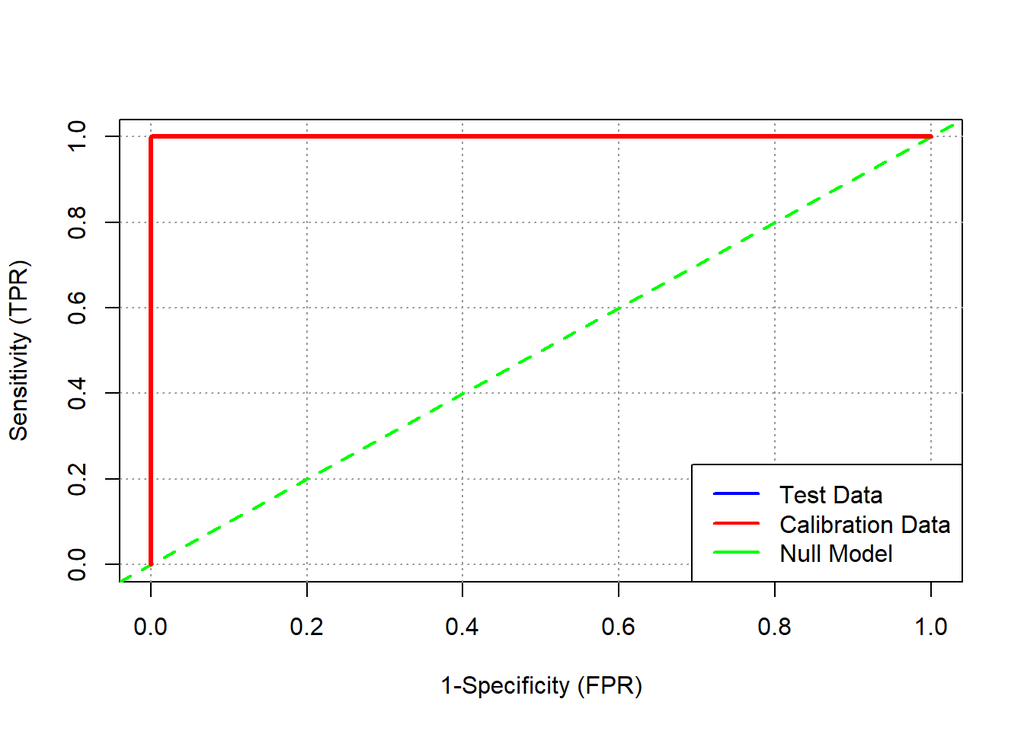

```
##
##
## model           precision   recall   f1   logLikelihood    dev.norm
## ------------- ----------- -------- ---- --------------- -----------
## calibration             1        1    1       -1.309343   4.515e-02
## test                    1        1    1       -0.000003   1.111e-07
```

```r
runDecisionTree(c('video_views_for_the_last_30_days', 'pred_created_full_date', 'subscribers_for_last_30_days'))
```

```
## Train AUC:  1
## Test AUC:  1
```

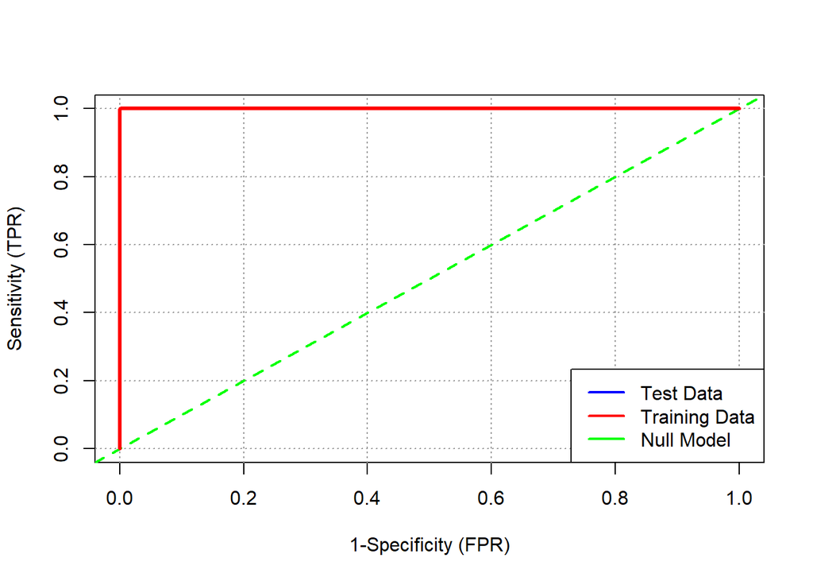

```
##
##
## model        precision   recall   f1   logLikelihood    dev.norm
## ---------- ----------- -------- ---- --------------- -----------
## training             1        1    1        -2.8e-05   1.343e-07
## test                 1        1    1        -3.0e-06   1.111e-07
```

Another feature selection technique used here is Forward Selection. It generally start from empty set, then add a new feature in each loop as long as the new combination can bring performance improvement. We here use AUC as the metric for performance evaluation.

Categorical variables are transformed into representing numerical ones for knn methods, as knn should only accept numeric attributes.

Both the knn and decision tree model select a single ‘video_views_for_the_last_30_days’ as final feature variables. Execute these 2 models with this variable and again we get very high accurate performance.

```r
selected_feature_catVars <- c("category", "Country", "channel_type")
pred_selected_feature_catVars <- paste('pred_', selected_feature_catVars, sep='')
features <-c(selected_feature_catVars, feature_numericVars)

# this for loop is to make sure test data set does not contain different categorical values that are not in the training set. Otherwise, the decision tree method will raise an error.
for (feature_catVar in selected_feature_catVars) {
  na.omit_dTest <-
    na.omit_dTest[na.omit_dTest[[feature_catVar]] %in% unique(na.omit_dTrain[[feature_catVar]]), ]
  na.omit_dCal <-
    na.omit_dCal [na.omit_dCal [[feature_catVar]] %in% unique(na.omit_dTrain[[feature_catVar]]), ]
}

run_forward_selection <- function(features, func) {
  selected_features <- NULL
  best_auc <- -Inf
  # Perform forward selection
  for (i in 1:length(features) - 1) {
    best_auc_inner <- best_auc
    best_feature <- NULL
    for (feature in setdiff(features, selected_features)) {
      current_features <- c(selected_features, feature)
      current_auc <- func(current_features, display = FALSE)
      if (current_auc > best_auc_inner) {
        best_auc_inner <- current_auc
        best_feature <- feature
      }
    }
    if (best_auc_inner > best_auc) {
      best_auc <- best_auc_inner
      selected_features <- c(selected_features, best_feature)
    }
    else{
      break
    }
  }

  cat(deparse(substitute(func)), ",final selected features:",
      paste(selected_features, collapse = ","),
      "\n")
  func(selected_features, display = T)

}

run_forward_selection(features,runDecisionTree)
```

```
## runDecisionTree ,final selected features: video_views_for_the_last_30_days
## Train AUC:  1
## Test AUC:  1
```

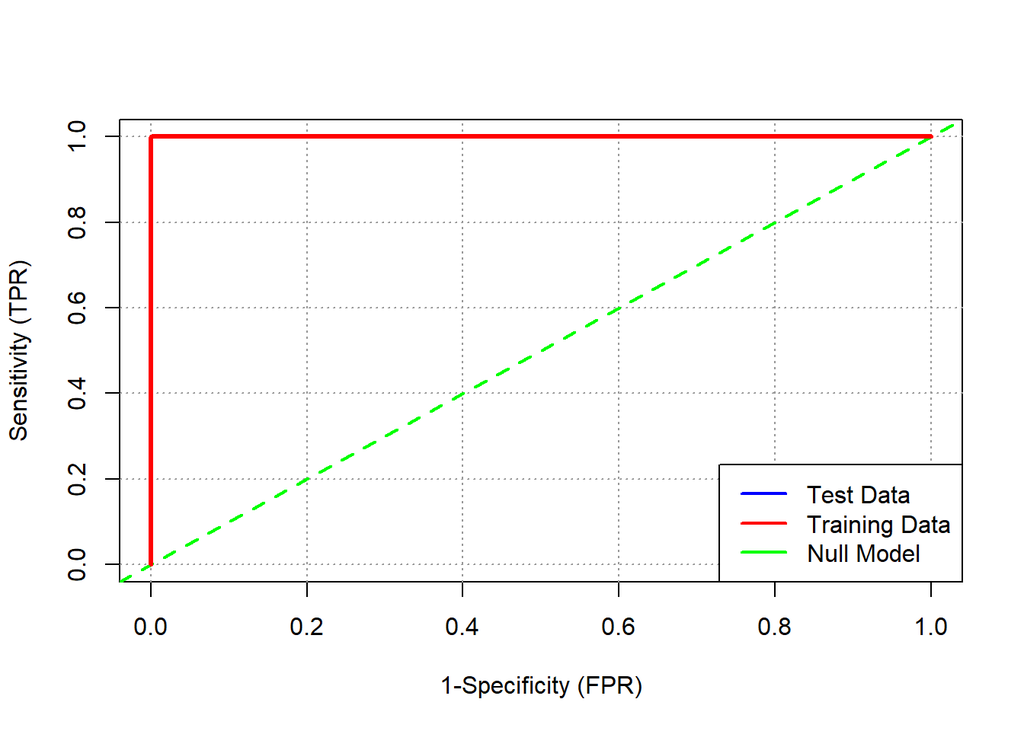

```
##
##
## model        precision   recall   f1   logLikelihood    dev.norm
## ---------- ----------- -------- ---- --------------- -----------
## training             1        1    1        -2.8e-05   1.343e-07
## test                 1        1    1        -3.0e-06   1.132e-07
```

```r
run_forward_selection(c(pred_selected_feature_catVars,feature_numericVars),run_knn)
```

```
## run_knn ,final selected features: video_views_for_the_last_30_days
## Calibration AUC:  1
## Test AUC:  1
```

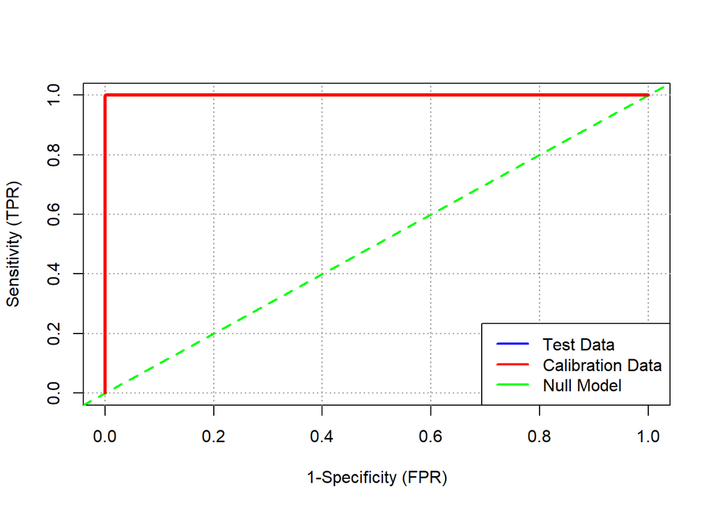

```
##
##
## model           precision   recall   f1   logLikelihood    dev.norm
## ------------- ----------- -------- ---- --------------- -----------
## calibration             1        1    1       -1.309343   4.515e-02
## test                    1        1    1       -0.000003   1.132e-07
```

### Clustering

Defining some useful methods from lecture slides.

```r
sqr_euDist <- function(x, y) {
    sum((x - y)^2)
}

wss <- function(clustermat) {
    c0 <- colMeans(clustermat)
    sum(apply( clustermat, 1, FUN=function(row) {sqr_euDist(row, c0)} ))
}

wss_total <- function(scaled_df, labels) {
    wss.sum <- 0
    k <- length(unique(labels))
    for (i in 1:k)
        wss.sum <- wss.sum + wss(subset(scaled_df, labels == i))
    wss.sum
}

tss <- function(scaled_df) {
   wss(scaled_df)
}

CH_index <- function(scaled_df, kmax, method="kmeans") {
    if (!(method %in% c("kmeans", "hclust")))
        stop("method must be one of c('kmeans', 'hclust')")
    npts <- nrow(scaled_df)
    wss.value <- numeric(kmax)
    wss.value[1] <- wss(scaled_df)

    if (method == "kmeans") {
        # kmeans
        for (k in 2:kmax) {
            clustering <- kmeans(scaled_df, k, nstart=10, iter.max=100)
            wss.value[k] <- clustering$tot.withinss
        }
    } else {
        # hclust
        d <- dist(scaled_df, method="euclidean")
        pfit <- hclust(d, method="ward.D2")
        for (k in 2:kmax) {
            labels <- cutree(pfit, k=k)
            wss.value[k] <- wss_total(scaled_df, labels)
        }
    }
    bss.value <- tss(scaled_df) - wss.value
    B <- bss.value / (0:(kmax-1))
    W <- wss.value / (npts - 1:kmax)

    data.frame(k = 1:kmax, CH_index = B/W, WSS = wss.value)
}
```

For clustering, we will combine training, calibration and test data sets together. The CH index and wss plots can help us find the optimal k value. In this case, k=2 should be the optimal value, it reflects the highest CH value and the wss plot seems constantly descending and does not give much info.

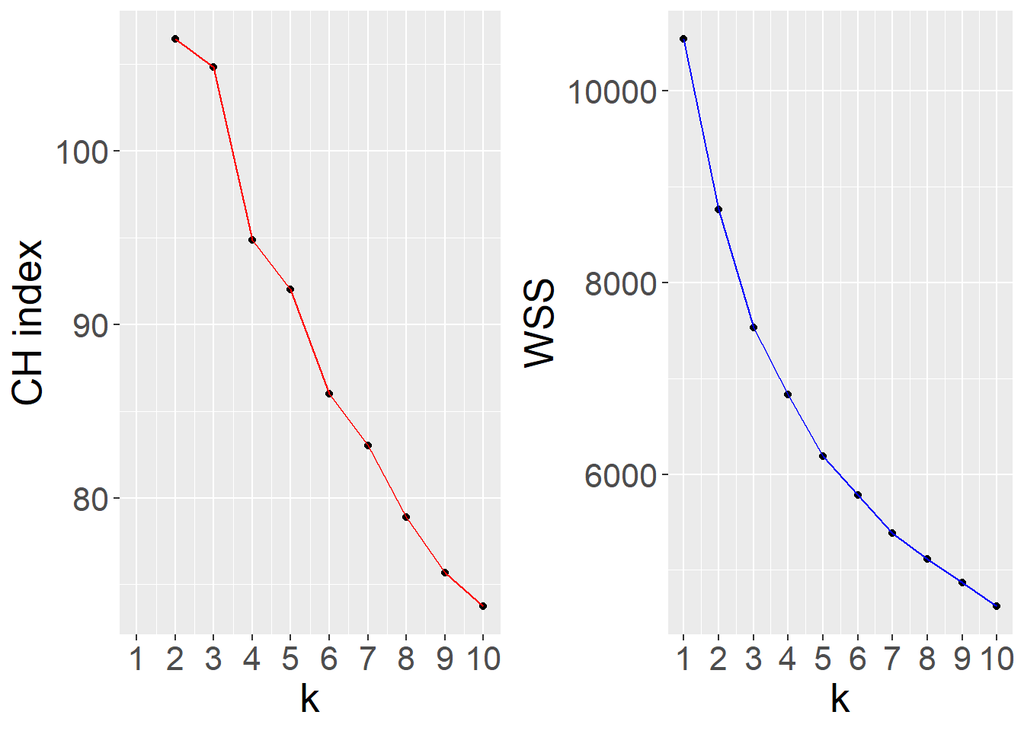

```r
df <- rbind(na.omit_dTrain, na.omit_dCal, na.omit_dTest)
# similar to knn, only numeric values are allowed
scaled_df <- scale(df[,c(pred_selected_feature_catVars,feature_numericVars)])

# calculate the CH criterion
crit.df <- CH_index(scaled_df, 10, method="hclust")

fig1 <- ggplot(crit.df, aes(x=k, y=CH_index)) +
  geom_point() + geom_line(colour="red") +
  scale_x_continuous(breaks=1:10, labels=1:10) +
  labs(y="CH index") + theme(text=element_text(size=20))

fig2 <- ggplot(crit.df, aes(x=k, y=WSS), color="blue") +
  geom_point() + geom_line(colour="blue") +
  scale_x_continuous(breaks=1:10, labels=1:10) +
  theme(text=element_text(size=20))

grid.arrange(fig1, fig2, nrow=1)
```

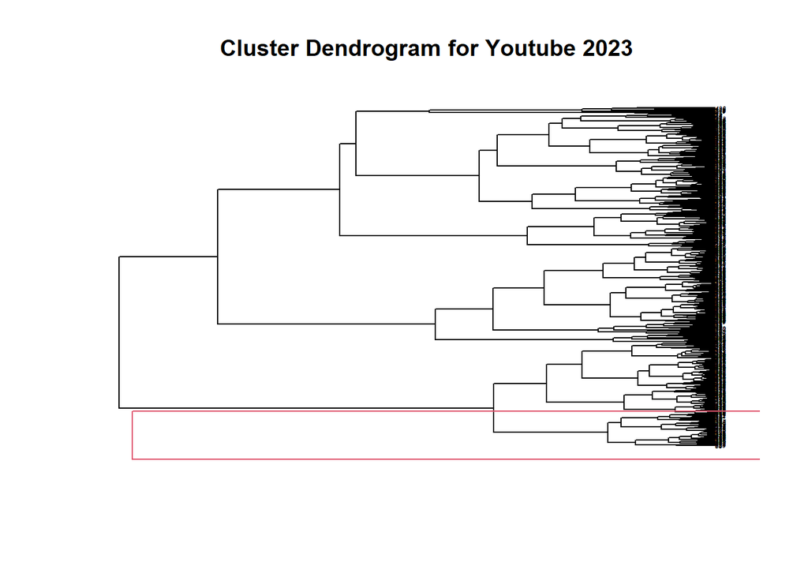

```r
##using dist function to calculate the distance matrix. ec
d <- dist(scaled_df, method="euclidean")

pfit <- hclust(d, method="ward.D2")
plot(as.phylo(pfit), labels=df$highest_yearly_earnings_cat,  cex = 0.3, direction = "right", main="Cluster Dendrogram for Youtube 2023")

rect.hclust(pfit, k=2)
```

```r
print_clusters <- function(df, groups, cols_to_print) {
  Ngroups <- max(groups)
  for (i in 1:Ngroups) {
    print(paste("cluster", i))
    print(df[groups == i, cols_to_print])
  }
}
```

We can label each group using ‘Country’ or ‘highest_yearly_earnings_cat’. The result shows the clustering essentially separate the data sets into US and non-US groups, which denotes the data pattern similarities within US country are higher than that in the other countries. Maybe if originally we choose ‘Country’ as target variable and use other columns to predict whether it’s US or non-US, we also can get very precise models.

```r
cboot.hclust <- clusterboot(scaled_df, clustermethod=hclustCBI,
                method="ward.D2", k=2, silent = TRUE)
```

[output not shown]

[output cut: 45 more lines]

[output not shown]

```r
summary(cboot.hclust$result)
```

```
##               Length Class  Mode
## result          7    hclust list
## noise           1    -none- logical
## nc              1    -none- numeric
## clusterlist     2    -none- list
## partition     528    -none- numeric
## clustermethod   1    -none- character
## nccl            1    -none- numeric
```

```r
groups.cboot <- cboot.hclust$result$partition
table(df[groups.cboot==1,"highest_yearly_earnings_cat"])
```

```
##
##  low_income high_income
##          22         344
```

```r
table(df[groups.cboot==2,"highest_yearly_earnings_cat"])
```

```
##
##  low_income high_income
##          15         147
```

```r
print_clusters(df, groups.cboot, "Country")
```

```
## [1] "cluster 1"
##   [1] "United States"        "India"                "India"
##   [4] "South Korea"          "Canada"               "South Korea"
##   [7] "India"                "India"                "India"
##  [10] "Argentina"            "India"                "India"
##  [13] "India"                "United Kingdom"       "Chile"
##  [16] "El Salvador"          "India"                "Brazil"
##  [19] "Brazil"               "Pakistan"             "Philippines"
##  [22] "Russia"               "India"                "Mexico"
##  [25] "United Arab Emirates" "India"                "Canada"
##  [28] "Thailand"             "Brazil"               "Saudi Arabia"
##  [31] "India"                "India"                "India"
##  [34] "India"                "Brazil"               "India"
##  [37] "India"                "India"                "Colombia"
##  [40] "Indonesia"            "India"                "India"
```

[output cut: 150 more lines]

```r
table(df[groups.cboot==1,"Country"])
```

```
##
##            Argentina               Brazil               Canada
##                   11                   31                    6
##                Chile                China             Colombia
##                    2                    1                    9
##              Ecuador                Egypt          El Salvador
##                    2                    2                    1
##               France              Germany                India
##                    2                    3                  139
##            Indonesia                Italy                Japan
##                   18                    2                    3
##               Jordan               Kuwait               Latvia
##                    3                    1                    1
##             Malaysia               Mexico          Netherlands
##                    1                   17                    2
##             Pakistan          Philippines               Russia
##                    4                    8                   13
##         Saudi Arabia            Singapore          South Korea
##                    6                    2                    9
##                Spain               Sweden          Switzerland
##                   10                    1                    1
##             Thailand               Turkey              Ukraine
##                   12                    3                    4
## United Arab Emirates       United Kingdom        United States
##                    7                   23                    4
##              Vietnam
##                    2
```

```r
table(df[groups.cboot==2,"Country"])
```

```
##
## United States
##           162
```

```r
sum(df[groups.cboot==2,"Country"]=="United States")
```

```
## [1] 162
```